# Simple Linear Regression and the Sampling Distribution of a Coefficient

Author

Emily Somerset

```r
library(tidyverse)
library(ggplot2)
```

# Setup

Suppose researchers are interested in whether increasing the amount of fertilizer applied to a plant is associated with greater plant growth.

They conduct an experiment where plants receive different amounts of fertilizer and, after a fixed period of time, the amount of growth is measured in centimeters.

Even if two plants receive exactly the same amount of fertilizer, they will not necessarily grow by exactly the same amount.

There are many other sources of variation:

- biological differences between plants;
- small environmental differences;
- measurement error;
- other factors that were not measured.

We can think of the observed growth as one realization from a random process, with randomness coming from these various sources of variation.

# The underlying relationship

Suppose that, for a specific amount of fertilizer $x$, plant growth is generated by the following random process:

$$Y = 10 + 3x + \varepsilon, \qquad \varepsilon \sim \text{Normal}(0,\sigma^2),$$
or equivalently,
$$Y \sim \text{Normal}(10 + 3x,\sigma^2),$$

where $Y$ is plant growth in centimetres; $x$ is the amount of fertilizer applied; and $\varepsilon$ represents random variation that is Normally distributed.

**Note:** You can use whichever model formulation you prefer. I personally like the second!

Okay, so for fertilizer $x=1$, $Y \sim \text{Normal}(13,\sigma^2)$ and for $x=3$, $Y \sim \text{Normal}(19,\sigma^2)$. Let’s visualize this distribution for $x=0,1,2,3,4,5$:

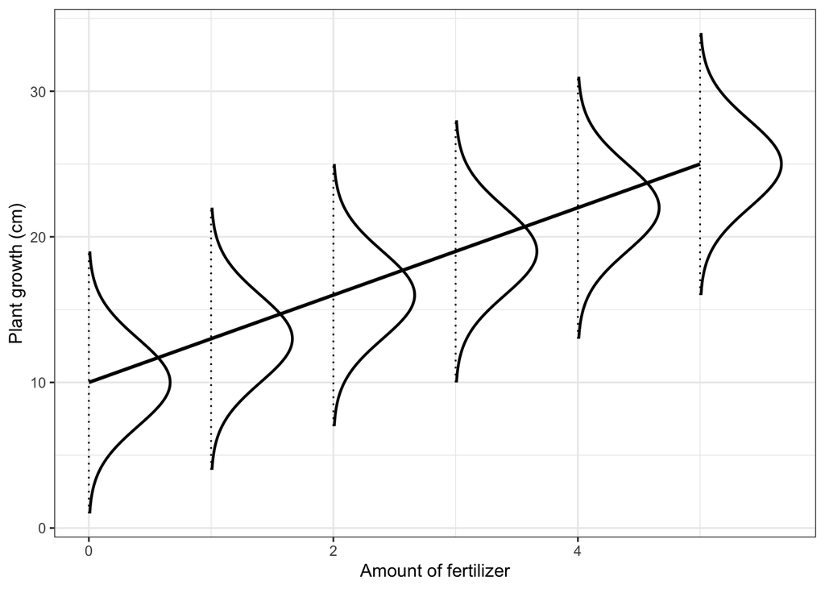

Each curve shows the distribution of possible plant growth values for a fixed amount of fertilizer. The centre of each distribution lies on the population line $10 + 3x$. This tells us the average plant growth we would expect at that amount of fertilizer. However, individual plants will not all have exactly this amount of growth. Because of random variation, their observed growth values will be scattered around the population line, with their density following the shape of the Normal distribution. Observations are more likely to fall near the centre of the distribution (population line) and become less likely as we move farther into either tail.

As the amount of fertilizer increases, the centre of the distribution moves upward along the population line. The spread of the distributions stays the same because the process has the same variance, $\sigma^2$, for every amount of fertilizer.

## Long story short

Don’t worry if some of the ideas above were confusing at first! You will encounter these concepts several times throughout your statistics courses, and they will become more familiar as you continue your statistics learning journey. Please don’t hesitate to ask me questions if anything is unclear.

The main takeaways are that the true (population) regression line is:

$$10 + 3x.$$

The population slope is:

$$\beta_1 = 3.$$

This means that, on average, increasing fertilizer by one unit is associated with an additional 3 cm of plant growth.

Importantly, this does **not** mean that every plant receiving the same fertilizer amount will grow by the same amount.

# One experiment

Suppose we conduct an experiment with 50 plants. Fertilizer values $x$ can take continuous values between 0 and 5. Notice here that I am modeling the random variations as Normal with standard deviation 3 and mean 0.

```r
set.seed(130)

n <- 50

experiment_1 <- tibble(
  fertilizer = runif(n, min = 0, max = 5),
  growth = 10 + 3 * fertilizer + rnorm(n, mean = 0, sd = 3)
)

experiment_1
```

```
# A tibble: 50 × 2
   fertilizer growth
        <dbl>  <dbl>
 1      4.75   23.3
 2      1.24   14.6
 3      1.49    9.76
 4      1.36   10.6
 5      2.92   18.1
 6      4.52   20.8
 7      0.663  11.9
 8      1.40   13.1
 9      0.814  18.9
10      3.51   23.9
# ℹ 40 more rows
```

## Visualize the data

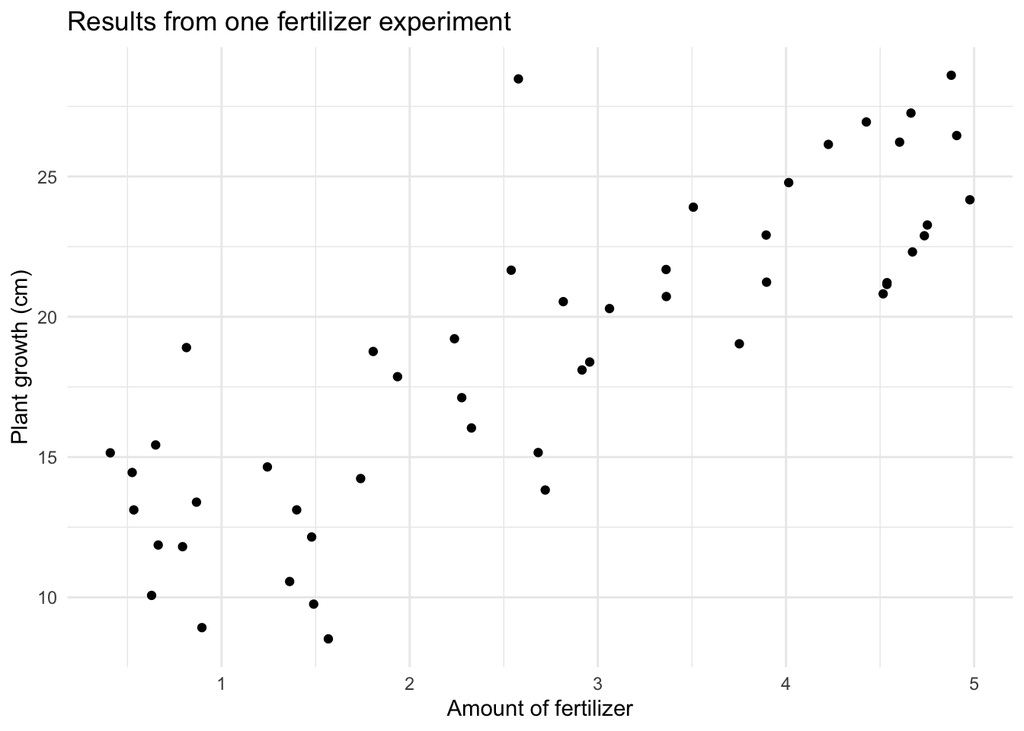

```r
ggplot(experiment_1, aes(x = fertilizer, y = growth)) +
  geom_point() +
  labs(
    x = "Amount of fertilizer",
    y = "Plant growth (cm)",
    title = "Results from one fertilizer experiment"
  ) +
  theme_minimal()
```

There appears to be a positive relationship between fertilizer and plant growth. There also appears to be a roughly constant spread of observations as the amount of fertilizer increases. Recall these observations are realizations from the random process we described above! Imagine drawing a small Normal distribution at each amount of fertilizer :)

# Fit a simple linear regression

```r
model_1 <- lm(growth ~ fertilizer, data = experiment_1)

summary(model_1)
```

```
Call:
lm(formula = growth ~ fertilizer, data = experiment_1)

Residuals:
    Min      1Q  Median      3Q     Max
-6.6393 -2.1506 -0.0427  2.1520 10.2533

Coefficients:
            Estimate Std. Error t value Pr(>|t|)
(Intercept)  10.3998     0.9207   11.30 4.04e-15 ***
fertilizer    3.0358     0.2966   10.24 1.17e-13 ***
---
Signif. codes:  0 '***' 0.001 '**' 0.01 '*' 0.05 '.' 0.1 ' ' 1

Residual standard error: 3.127 on 48 degrees of freedom
Multiple R-squared:  0.6858,    Adjusted R-squared:  0.6793
F-statistic: 104.8 on 1 and 48 DF,  p-value: 1.172e-13
```

Extract the estimated coefficients:

```r
coef(model_1)
```

```
(Intercept)  fertilizer
  10.399828    3.035832
```

Extract the estimated slope:

```r
slope_1 <- coef(model_1)[["fertilizer"]]

slope_1
```

```
[1] 3.035832
```

The true slope in the process generating the data is:

```r
true_slope <- 3

true_slope
```

```
[1] 3
```

The estimated slope will usually not be exactly equal to 3.

Why?

Because the observed data are only **one set of realizations of the experiment**. We can redo the experiment and get a different set of realizations. Because of the randomness in the process (discussed above), these realizations will be randomly scattered around the true population line, 10 + 3*fertilizer. Therefore, depending on the particular realizations we observe, the line we fit to the data (our estimated slope and intercept) will vary from experiment to experiment.

## Visualize the fitted regression line

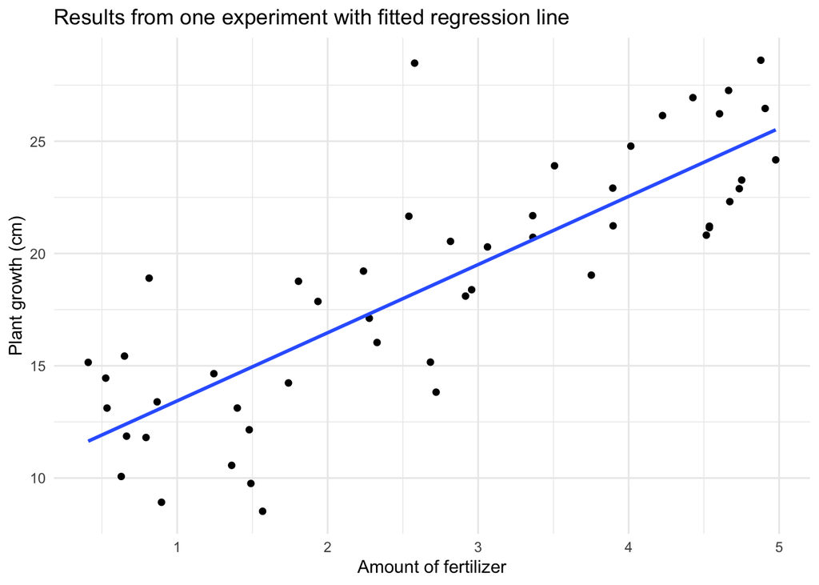

```r
ggplot(experiment_1, aes(x = fertilizer, y = growth)) +
  geom_point() +
  geom_smooth(method = "lm", se = FALSE) +
  labs(
    x = "Amount of fertilizer",
    y = "Plant growth (cm)",
    title = "Results from one experiment with fitted regression line"
  ) +
  theme_minimal()
```

We can also compare the fitted line with the underlying average relationship.

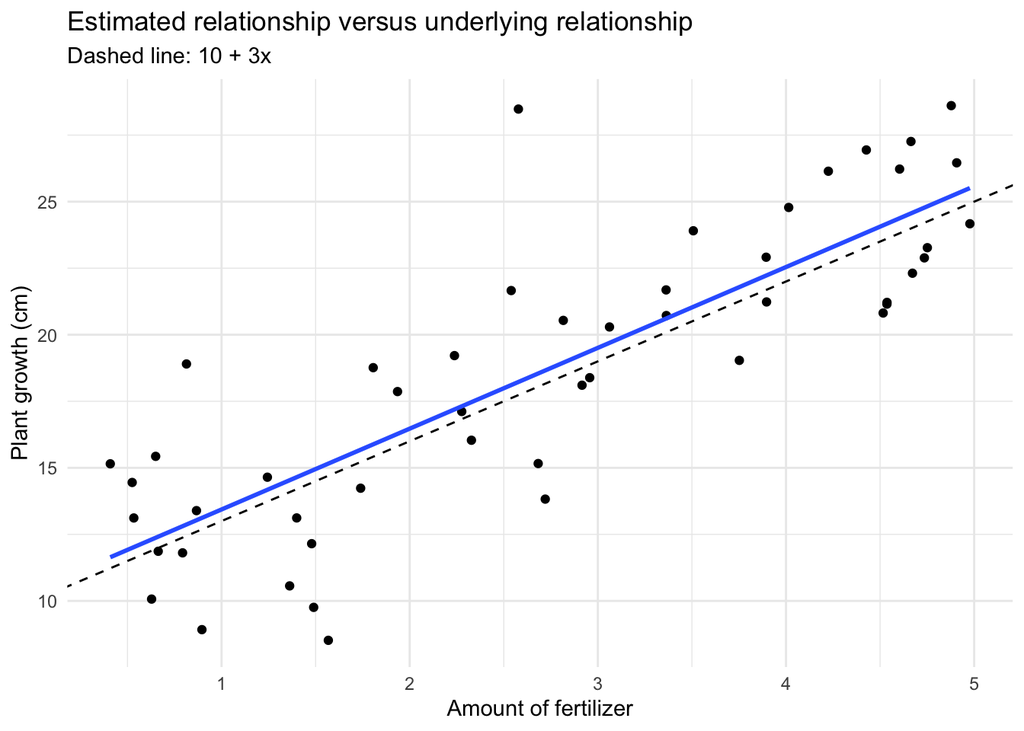

```r
ggplot(experiment_1, aes(x = fertilizer, y = growth)) +
  geom_point() +
  geom_abline(
    intercept = 10,
    slope = 3,
    linetype = "dashed"
  ) +
  geom_smooth(method = "lm", se = FALSE) +
  labs(
    x = "Amount of fertilizer",
    y = "Plant growth (cm)",
    title = "Estimated relationship versus underlying relationship",
    subtitle = "Dashed line: 10 + 3x"
  ) +
  theme_minimal()
```

# What if we repeated the experiment?

Imagine that another researcher repeats the same experiment with 50 new plants.

The same experimental process is used, but the observed plant growth values will not be identical.

```r
set.seed(131)

experiment_2 <- tibble(
  fertilizer = runif(n, min = 0, max = 5),
  growth = 10 + 3 * fertilizer + rnorm(n, mean = 0, sd = 3)
)

model_2 <- lm(growth ~ fertilizer, data = experiment_2)

coef(model_2)
```

```
(Intercept)  fertilizer
   9.913518    2.962897
```

Compare the two estimated slopes:

```r
coef(model_1)[["fertilizer"]]
```

```
[1] 3.035832
```

```r
coef(model_2)[["fertilizer"]]
```

```
[1] 2.962897
```

Both experiments were generated by the same underlying relationship.

But the estimated slopes are different.

This is **sampling variability**.

Here, repeated sampling means repeating the data-generating process and observing another possible dataset.

# Keep on repeating

Suppose we could repeat the fertilizer experiment many times.

Each time we:

1. conduct the experiment on 50 plants;
2. observe plant growth;
3. fit a regression model;
4. record the estimated fertilizer coefficient.

Let’s repeat the process 1,000 times.

```r
set.seed(130)

B <- 1000

simulation_results <- tibble(
  experiment = 1:B
) |>
  mutate(
    slope = map_dbl(
      experiment,
      \(i) {
       # Reconducting the experiment to observe 50 new observations
        dat <- tibble(
          fertilizer = runif(n, min = 0, max = 5),
          growth = 10 + 3 * fertilizer + rnorm(n, mean = 0, sd = 3)
        )
        # Fit regression model
        fit <- lm(growth ~ fertilizer, data = dat)

        coef(fit)[["fertilizer"]]
      }
    )
  )

simulation_results
```

```
# A tibble: 1,000 × 2
   experiment slope
        <int> <dbl>
 1          1  3.04
 2          2  2.66
 3          3  3.13
 4          4  3.46
 5          5  2.45
 6          6  2.83
 7          7  3.37
 8          8  3.00
 9          9  2.83
10         10  3.43
# ℹ 990 more rows
```

# The sampling distribution of the slope

Each repeated experiment gives us one estimate:

$$\widehat{\beta}_1$$

Across repeated experiments, we obtain

$$\widehat{\beta}_1^{(1)},
\widehat{\beta}_1^{(2)},
\ldots,
\widehat{\beta}_1^{(1000)}$$

The distribution of these possible estimates is called the **sampling distribution of the slope estimator**. To visualize this sampling distribution in our example, we can plot a histogram of the slope estimates obtained across all of our repeated samples.

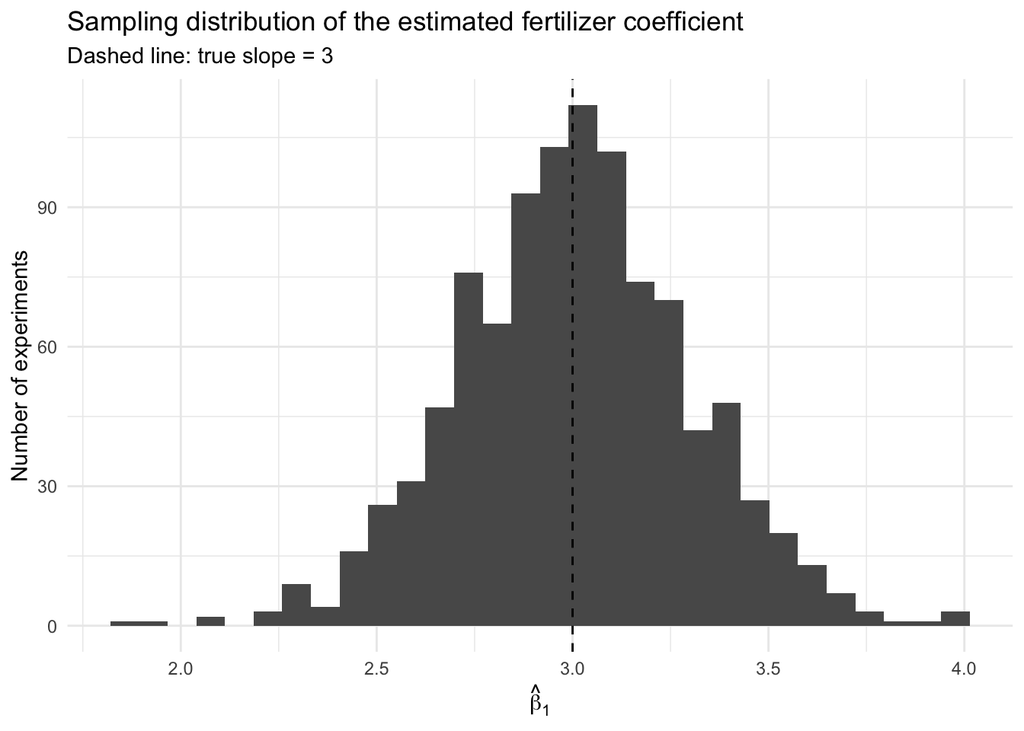

```r
ggplot(simulation_results, aes(x = slope)) +
  geom_histogram(bins = 30) +
  geom_vline(
    xintercept = true_slope,
    linetype = "dashed"
  ) +
  labs(
    x = expression(hat(beta)[1]),
    y = "Number of experiments",
    title = "Sampling distribution of the estimated fertilizer coefficient",
    subtitle = "Dashed line: true slope = 3"
  ) +
  theme_minimal()
```

## Centre of the sampling distribution

Calculate the average estimated slope across the 1,000 experiments.

```r
mean(simulation_results$slope)
```

```
[1] 3.004372
```

Compare it with the true slope.

```r
true_slope
```

```
[1] 3
```

The estimates vary from experiment to experiment, but they tend to be centered around the true value!!! We love this.

## Spread of the sampling distribution

The estimates are not all equal.

Calculate the standard deviation of the 1,000 estimated slopes.

```r
sd(simulation_results$slope)
```

```
[1] 0.2963149
```

This tells us roughly how much the slope estimate changes from experiment to experiment.

The standard deviation of the sampling distribution of an estimator is called its **standard error**.

# What happens if we use more plants?

Suppose we repeat the experiment using different sample sizes.

Compare:

- 20 plants;
- 50 plants;
- 200 plants.

Let’s visually estimate the sampling distribution (using the same procedure as above) for these 3 different scenarios.

```r
simulate_slopes <- function(n, B = 1000) {

  tibble(
    experiment = 1:B
  ) |>
    mutate(
      slope = map_dbl(
        experiment,
        \(i) {

          dat <- tibble(
            fertilizer = runif(n, min = 0, max = 5),
            growth = 10 + 3 * fertilizer + rnorm(n, mean = 0, sd = 3)
          )

          coef(
            lm(growth ~ fertilizer, data = dat)
          )[["fertilizer"]]
        }
      ),
      sample_size = n
    )
}
```

```r
set.seed(130)

sample_size_results <- bind_rows(
  simulate_slopes(n = 20),
  simulate_slopes(n = 50),
  simulate_slopes(n = 200)
)
```

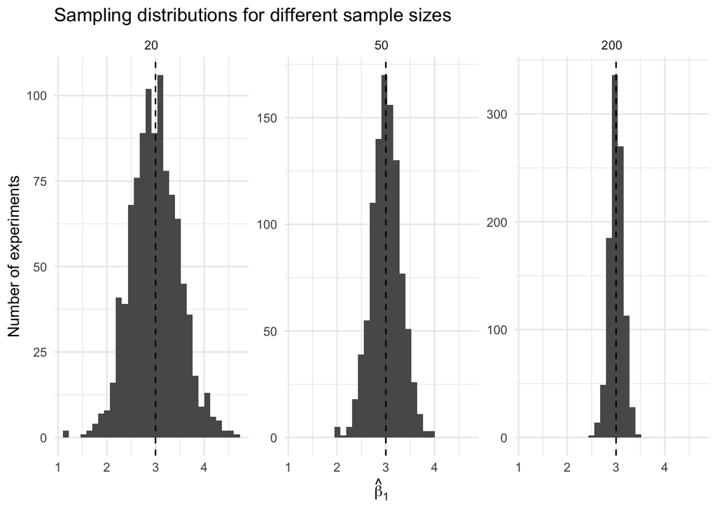

```r
sample_size_results |>
  ggplot(aes(x = slope)) +
  geom_histogram(bins = 30) +
  geom_vline(
    xintercept = true_slope,
    linetype = "dashed"
  ) +
  facet_wrap(~ sample_size, scales = "free_y") +
  labs(
    x = expression(hat(beta)[1]),
    y = "Number of experiments",
    title = "Sampling distributions for different sample sizes"
  ) +
  theme_minimal()
```

Summarize the distributions:

```r
sample_size_results |>
  group_by(sample_size) |>
  summarize(
    mean_slope = mean(slope),
    sampling_sd = sd(slope)
  )
```

```
# A tibble: 3 × 3
  sample_size mean_slope sampling_sd
        <dbl>      <dbl>       <dbl>
1          20       2.99       0.496
2          50       3.00       0.301
3         200       3.01       0.145
```

As the number of plants increases:

- the estimated slopes remain centered around the true slope;
- the spread of the sampling distribution decreases;
- our estimate of the fertilizer effect is said to become more precise (precision is a statistics term).

# Explain it in your own words <3

1. Why do two repetitions of the fertilizer experiment produce different estimated slopes?
2. Which quantity is fixed: $\beta_1$ or $\widehat{\beta}_1$?
3. What does each observation in the histogram of simulated slopes represent?
4. What does the standard deviation of the sampling distribution tell us?
5. Why does increasing the number of plants make the sampling distribution narrower?